# Report PeerAssessment1

Guillermo ATT

11 de enero de 2017

## 1. Code for reading in the data and/or processing the data

```r
library(ggplot2)
unzip("activity.zip")
data<-read.csv("activity.csv",stringsAsFactors = FALSE)
data$date<-as.Date(data$date,format="%Y-%m-%d")
data$interval<-as.factor(data$interval)
## The structure of the data frame is shown below
str(data)
```

```
## 'data.frame':    17568 obs. of  3 variables:
##  $ steps   : int  NA NA NA NA NA NA NA NA NA NA ...
##  $ date    : Date, format: "2012-10-01" "2012-10-01" ...
##  $ interval: Factor w/ 288 levels "0","5","10","15",..: 1 2 3 4 5 6 7 8 9 10 ...
```

## 2. Histogram of the total number of steps each day

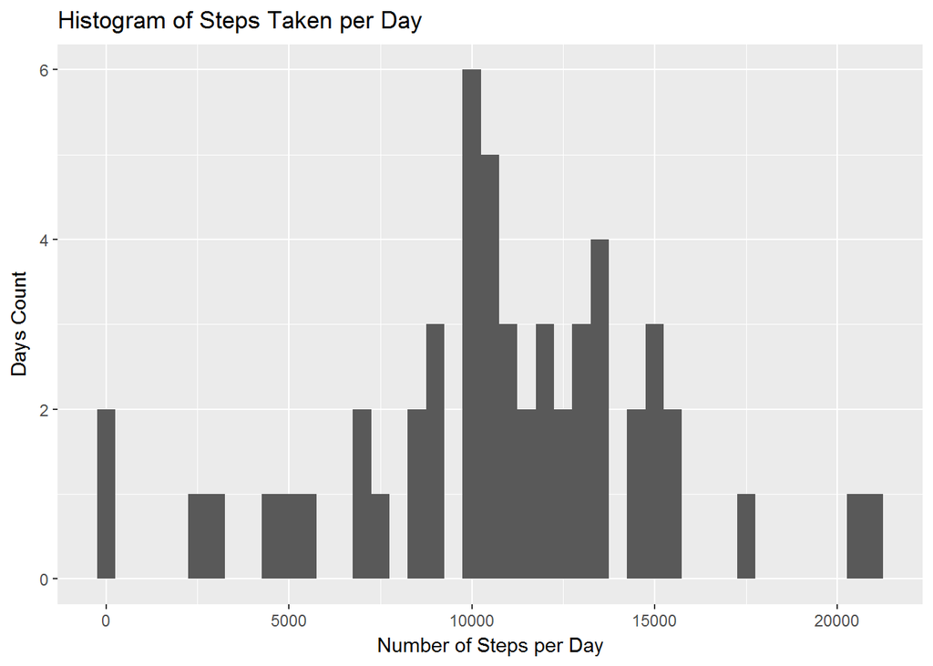

```r
## We first load the neccesary library
library(ggplot2)
stepseachday<-tapply(data$steps,data$date,sum)
qplot(stepseachday,binwidth=500)+labs(title="Histogram of Steps Taken per Day",  x = "Number of Steps per Day", y = "Days Count")
```

```r
str(stepseachday)
```

```
##  int [1:61(1d)] NA 126 11352 12116 13294 15420 11015 NA 12811 9900 ...
##  - attr(*, "dimnames")=List of 1
##   ..$ : chr [1:61] "2012-10-01" "2012-10-02" "2012-10-03" "2012-10-04" ...
```

```r
typeof(stepseachday)
```

```
## [1] "integer"
```

## 3. Mean and median number of steps taken

```r
mean(stepseachday,na.rm=TRUE)
```

```
## [1] 10766.19
```

```r
median(stepseachday,na.rm=TRUE)
```

```
## [1] 10765
```

## 4. Timeserie plot of the average number of steps taken for each 5 min interval

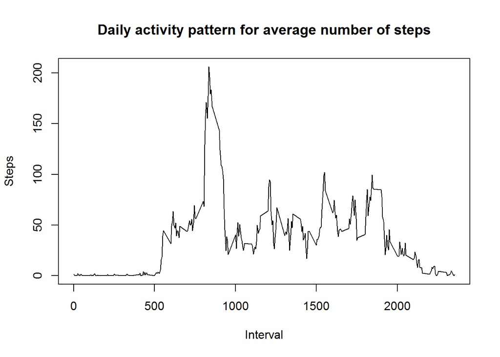

```r
steps_per_interval<-tapply(data$steps,data$interval,mean,na.rm=TRUE)
x<-unlist(attr(steps_per_interval,"dimnames"))
plot(x,steps_per_interval,
     type="l",xlab="Interval",ylab="Steps",
     main="Daily activity pattern for average number of steps")
```

## 5. The 5 min interval that, on average, contains the max number of steps

```r
max<- which.max(steps_per_interval)
names(steps_per_interval[max])
```

```
## [1] "835"
```

**835** is the 5 min interval with the maximum number of steps on average that are **206.1698113**

## 6. Code to describe and show a strategy for imputing missing data

```r
missing<-sum(is.na(data$steps))
percentage<-mean(is.na(data$steps))
```

We now proceed to impute the missing values with the mean values for the same intervals

```r
fill.value <- function(steps, interval) {
    filled <- NA
    if (!is.na(steps))
        filled <- c(steps)
    else
        filled <- (steps_per_interval[interval])
    return(filled)
}
filled.data <- data
filled.data$steps <- mapply(fill.value, filled.data$steps, filled.data$interval)
str(filled.data)
```

```
## 'data.frame':    17568 obs. of  3 variables:
##  $ steps   : num  1.717 0.3396 0.1321 0.1509 0.0755 ...
##  $ date    : Date, format: "2012-10-01" "2012-10-01" ...
##  $ interval: Factor w/ 288 levels "0","5","10","15",..: 1 2 3 4 5 6 7 8 9 10 ...
```

We can check that there are no missing values

```r
sum(is.na(filled.data$steps))
```

```
## [1] 0
```

## 7. Histogram of the total number of steps taken each day after missing values are imputed

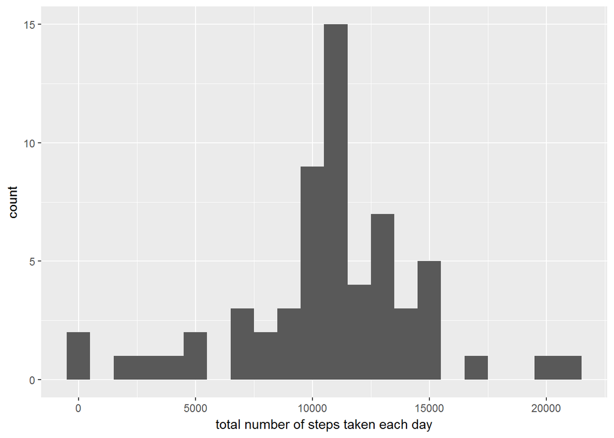

```r
total.steps <- tapply(filled.data$steps, filled.data$date, FUN=sum)
qplot(total.steps, binwidth=1000, xlab="total number of steps taken each day")
```

## 8. Panel plot comparing the average number of steps taken per 5 minute interval across weekdays and weekends

```r
weekdayorweekend <- function(date) {
    day <- weekdays(date)
    if (day %in% c("lunes", "martes", "miércoles", "jueves", "viernes"))
        return("weekday")
    else if (day %in% c("sábado", "domingo"))
        return("weekend")
    else
        stop("invalid date")
}
filled.data$day <- sapply(filled.data$date, FUN=weekdayorweekend)
table(filled.data$day)
```

```
##
## weekday weekend
##   12960    4608
```

```r
str(filled.data)
```

```
## 'data.frame':    17568 obs. of  4 variables:
##  $ steps   : num  1.717 0.3396 0.1321 0.1509 0.0755 ...
##  $ date    : Date, format: "2012-10-01" "2012-10-01" ...
##  $ interval: Factor w/ 288 levels "0","5","10","15",..: 1 2 3 4 5 6 7 8 9 10 ...
##  $ day     : chr  "weekday" "weekday" "weekday" "weekday" ...
```

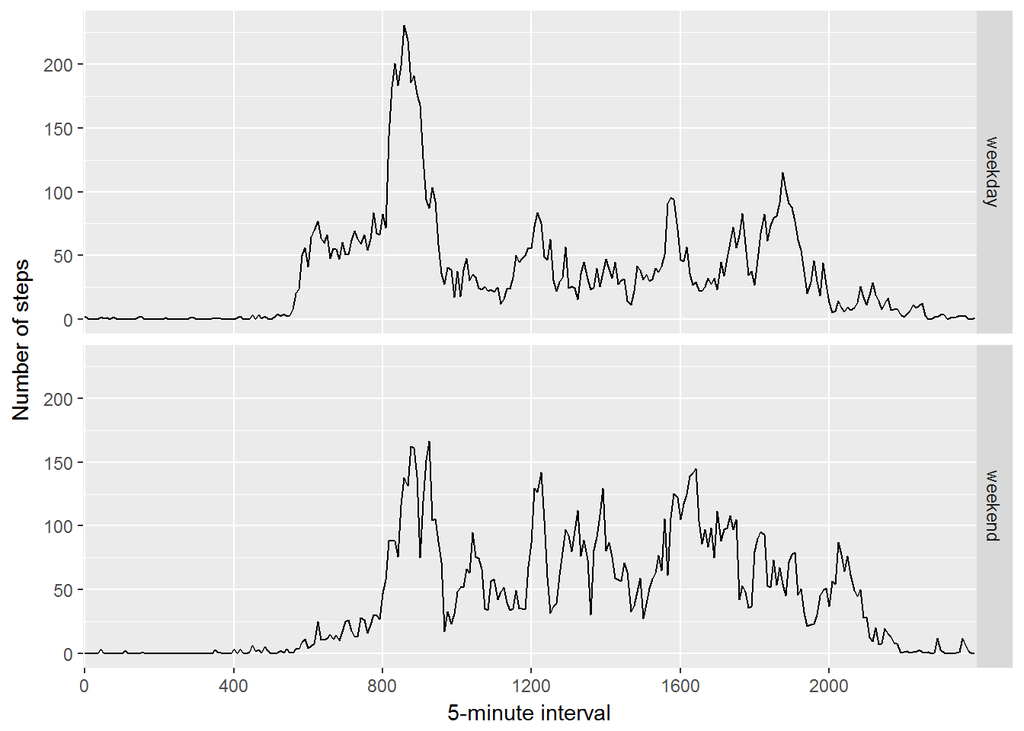

```r
averages <- aggregate(steps ~ interval + day, data=filled.data, mean)
ggplot(averages, aes(interval, steps,group=1)) + geom_line() + facet_grid(day ~ .)+ scale_x_discrete(breaks=c(0,400,800,1200,1600,2000,2400)) +  xlab("5-minute interval") + ylab("Number of steps")
```